# Merging & advanced manipulations

```r
library(dplyr)
library(tidyr)

bf <- readr::read_csv(here::here("data", "bigfoot.csv"))
```

# Reshaping (pivoting)

Remember when we did this earlier:

```r
bf |> summarise(across(everything(), function(x) sum(is.na(x))))
```

```
#> # A tibble: 1 × 28
#>   observed location_details county state season title latitude longitude  date
#>      <int>            <int>  <int> <int>  <int> <int>    <int>     <int> <int>
#> 1       38              758      0     0      0   976      976       976   976
#> # ℹ 19 more variables: number <int>, classification <int>, geohash <int>,
#> #   temperature_high <int>, temperature_mid <int>, temperature_low <int>,
#> #   dew_point <int>, humidity <int>, cloud_cover <int>, moon_phase <int>,
#> #   precip_intensity <int>, precip_probability <int>, precip_type <int>,
#> #   pressure <int>, summary <int>, uv_index <int>, visibility <int>,
#> #   wind_bearing <int>, wind_speed <int>
```

It looked kind of stupid, right? It’s too… wide?! Wouldn’t it be better if we had a column that holds the variable, and one that holds the number of missing values? Then we could also use all of our tricks (`arrange()` etc.) again! The solution comes from the `tidyr`-package, part of the tidyverse & dplyr’s “brother”:

```r
wide_data <- bf |> summarise(across(everything(), function(x) sum(is.na(x))))

wide_data |>
  pivot_longer(cols = everything(), names_to = "variable", values_to = "missings")
```

```
#> # A tibble: 28 × 2
#>    variable         missings
#>    <chr>               <int>
#>  1 observed               38
#>  2 location_details      758
#>  3 county                  0
#>  4 state                   0
#>  5 season                  0
#>  6 title                 976
#>  7 latitude              976
#>  8 longitude             976
#>  9 date                  976
#> 10 number                  0
#> # ℹ 18 more rows
```

Using our tricks again to find the variables with the most missings:

```r
wide_data |>
  pivot_longer(cols = everything(), names_to = "variable", values_to = "missings") |>
  arrange(desc(missings))
```

```
#> # A tibble: 28 × 2
#>    variable           missings
#>    <chr>                 <int>
#>  1 precip_type            3298
#>  2 pressure               2402
#>  3 precip_probability     2311
#>  4 precip_intensity       2309
#>  5 visibility             1972
#>  6 cloud_cover            1937
#>  7 temperature_mid        1835
#>  8 temperature_low        1832
#>  9 temperature_high       1683
#> 10 summary                1655
#> # ℹ 18 more rows
```

“Wide” data is common in the wild. For example, the World Bank Development Indicators come in this format:

```r
fertility <- readr::read_csv(here::here("data", "wbi_fertility.csv"))
fertility
```

```
#> # A tibble: 266 × 65
#>    CountryName      CountryCode `1960` `1961` `1962` `1963` `1964` `1965` `1966`
#>    <chr>            <chr>       <chr>  <chr>  <chr>  <chr>  <chr>  <chr>  <chr>
#>  1 Afghanistan      AFG         138.8… 138.7… 138.4… 138.1… 140.1… 140.9… 142.8…
#>  2 Albania          ALB         59.371 56.719 47.62  40.433 39.268 41.521 42.389
#>  3 Algeria          DZA         123.1… 124.1… 123.9… 123.6… 123.2… 121.6… 119.3…
#>  4 American Samoa   ASM         53.75  56.67  58.531 59.651 56.865 55.951 56.091
#>  5 Andorra          AND         14.624 15.517 16.559 17.461 18.334 18.214 18.232
#>  6 Angola           AGO         148.2… 150.2… 150.8… 153.0… 155.6… 156.3… 157.45
#>  7 Antigua and Bar… ATG         130.75 129.6… 129.6… 130.6… 130.3… 128.5… 127.2…
#>  8 Argentina        ARG         54.977 54.219 55.718 55.292 56.305 57.4   58.684
#>  9 Armenia          ARM         50.24  44.673 35.681 33.444 38.036 41.236 43.512
#> 10 Aruba            ABW         62.182 61.589 61.17  59.658 58.324 56.291 54.201
#> # ℹ 256 more rows
#> # ℹ 56 more variables: `1967` <chr>, `1968` <chr>, `1969` <chr>, `1970` <chr>,
#> #   `1971` <chr>, `1972` <chr>, `1973` <chr>, `1974` <chr>, `1975` <chr>,
#> #   `1976` <chr>, `1977` <chr>, `1978` <chr>, `1979` <chr>, `1980` <chr>,
#> #   `1981` <chr>, `1982` <chr>, `1983` <chr>, `1984` <chr>, `1985` <chr>,
#> #   `1986` <chr>, `1987` <chr>, `1988` <chr>, `1989` <chr>, `1990` <chr>,
#> #   `1991` <chr>, `1992` <chr>, `1993` <chr>, `1994` <chr>, `1995` <chr>, …
```

Let’s put this one into long format as well:

```r
fert_long <-
  fertility |>
  pivot_longer(
    cols = -starts_with("Country"),
    names_to = "year",
    values_to = "fertility"
  )

fert_long
```

```
#> # A tibble: 16,758 × 4
#>    CountryName CountryCode year  fertility
#>    <chr>       <chr>       <chr> <chr>
#>  1 Afghanistan AFG         1960  138.876
#>  2 Afghanistan AFG         1961  138.717
#>  3 Afghanistan AFG         1962  138.494
#>  4 Afghanistan AFG         1963  138.173
#>  5 Afghanistan AFG         1964  140.107
#>  6 Afghanistan AFG         1965  140.935
#>  7 Afghanistan AFG         1966  142.821
#>  8 Afghanistan AFG         1967  143.154
#>  9 Afghanistan AFG         1968  142.341
#> 10 Afghanistan AFG         1969  141.28
#> # ℹ 16,748 more rows
```

**Exercise time:** Look at the documentation for `?pivot_wider`. Try to use it to put our long data frame (`fert_long`) back into the original “wide” format! *Tip:* If you scroll down in the documentation, you get to the code examples. Examples often say more than a thousand explanations… *Tip 2:* You only need two of the arguments: `names_from` and `values_from`.

```r
# Your code here
```

# Merging (joining)

```r
educ <- readr::read_csv(here::here("data", "wbi_education.csv"))
```

**Exercise time:** Thanks to the World Bank, the data is again in wide format (oh no!). Fix this using `pivot_longer()`! The variable is the ratio of high school age females out of school, so give it an appropriate name.

```r
# Your code here
```

Okay, now we have both datasets in order… But, how do we put them together? If we look closely, we see that both of them share three columns: `CountryName` & `CountryCode`, and of course the `year`, which we can use to match observations!

There are different ways of merging (or “joining”) the education data to our fertility data:

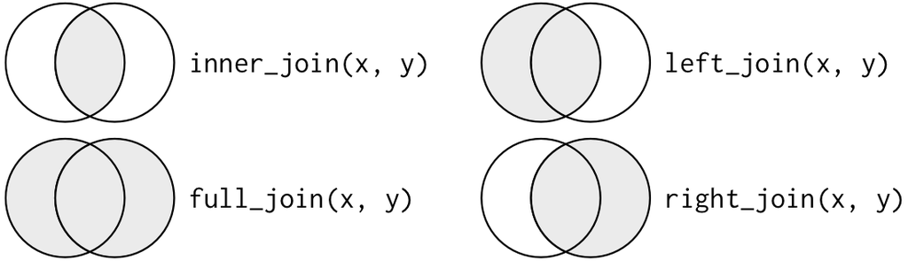

Here is the solution for above btw (needed for joining):

```r
educ <-
  educ |>
  pivot_longer(
    cols = -starts_with("Country"),
    names_to = "year",
    values_to = "females_out_of_school"
  ) |>
  select(-CountryName) # we also won't need this since it's in both data frames
```

For example:

```r
left_join(fert_long, educ, by = c("CountryCode", "year"))
```

```
#> # A tibble: 16,758 × 5
#>    CountryName CountryCode year  fertility females_out_of_school
#>    <chr>       <chr>       <chr> <chr>                     <dbl>
#>  1 Afghanistan AFG         1960  138.876                      NA
#>  2 Afghanistan AFG         1961  138.717                      NA
#>  3 Afghanistan AFG         1962  138.494                      NA
#>  4 Afghanistan AFG         1963  138.173                      NA
#>  5 Afghanistan AFG         1964  140.107                      NA
#>  6 Afghanistan AFG         1965  140.935                      NA
#>  7 Afghanistan AFG         1966  142.821                      NA
#>  8 Afghanistan AFG         1967  143.154                      NA
#>  9 Afghanistan AFG         1968  142.341                      NA
#> 10 Afghanistan AFG         1969  141.28                       NA
#> # ℹ 16,748 more rows
```

Keeps all observations from `fert_long`, and adds matching observations from `educ` based on CountryCode and year. Check the number of rows in the joined data above, and in `fert_long`:

```r
nrow(fert_long)
```

```
#> [1] 16758
```

They are the same, because we simply add in observations from `educ` into `fert_long` where possible!

A `right_join()` would do the exact opposite. An `inner_join()` only keeps CountryCode-year combinations that exist in both data frames, and a `full_join()` keeps all that exist in *either* of the two. Let’s stick to an `inner_join()`:

```r
full <-
  fert_long |>
  inner_join(educ, by = c("CountryCode", "year")) |>
  select(-starts_with("CountryN")) |>
  rename("country" = CountryCode) |>
  mutate(across(c(fertility, females_out_of_school), as.numeric)) |>
  drop_na()

full
```

```
#> # A tibble: 2,404 × 4
#>    country year  fertility females_out_of_school
#>    <chr>   <chr>     <dbl>                 <dbl>
#>  1 AFG     1974     143.                   94.6
#>  2 ALB     2000      14.8                   7.58
#>  3 ALB     2001       9.70                  4.59
#>  4 ALB     2017      16.6                   2.84
#>  5 ALB     2020      14.7                   5.30
#>  6 ALB     2021      14.5                   6.10
#>  7 DZA     1984      45.9                  49.6
#>  8 DZA     1995      19.1                  32.7
#>  9 DZA     1996      16.7                  32.5
#> 10 DZA     1997      13.3                  27.8
#> # ℹ 2,394 more rows
```

Now that we have the two data sets together & clean, we can finally do our analysis! This time we will not do normal OLS (`lm()`) like the last times. Since R is a language built from the ground up for statistics, there are modelling packages for just about anything. Here, as an example, we will estimate the within-country effect to adjust for time-invariant heterogeneity between countries, using a fixed-effects model:

```r
library(fixest)

model <- feols(
  fertility ~ females_out_of_school,
  data = full,
  fixef = "country", # country fixed-effects
  vcov = ~country    # standard errors clustered by country (vcov = Variance-Covariance matrix)
)

summary(model)
```

```
#> OLS estimation, Dep. Var.: fertility
#> Observations: 2,404
#> Fixed-effects: country: 189
#> Standard-errors: Clustered (country)
#>                       Estimate Std. Error t value   Pr(>|t|)
#> females_out_of_school 0.893338   0.143206 6.23813 2.8614e-09 ***
#> ---
#> Signif. codes:  0 '***' 0.001 '**' 0.01 '*' 0.05 '.' 0.1 ' ' 1
#> RMSE: 11.3     Adj. R2: 0.933043
#>              Within R2: 0.34102
```

(Again I caution against any interpretation, we are not doing serious stuff here; this is just an example without substantive meaning)

# Bonus: programmatically filling missing values & lagging

If we look at the original `educ`ation data, we see a lot of missing values:

```r
educ
```

```
#> # A tibble: 13,832 × 3
#>    CountryCode year  females_out_of_school
#>    <chr>       <chr>                 <dbl>
#>  1 AFG         1971                   NA
#>  2 AFG         1972                   NA
#>  3 AFG         1973                   NA
#>  4 AFG         1974                   94.6
#>  5 AFG         1975                   NA
#>  6 AFG         1976                   NA
#>  7 AFG         1977                   NA
#>  8 AFG         1978                   NA
#>  9 AFG         1979                   NA
#> 10 AFG         1980                   NA
#> # ℹ 13,822 more rows
```

We can `fill()` them up using the last or next known previous value (remember to do this *by unit* if your data is a cross-sectional time series, or observations will carry across units!):

```r
educ_filled <-
  educ |>
  # Make sure to group by units if this applies:
  group_by(CountryCode) |>
  # And make sure your data is arranged properly:
  arrange(year, .by_group = TRUE) |>
  fill(females_out_of_school, .direction = "downup") |>
  ungroup() |>
  drop_na()

educ_filled
```

```
#> # A tibble: 9,880 × 3
#>    CountryCode year  females_out_of_school
#>    <chr>       <chr>                 <dbl>
#>  1 ABW         1971                   6.59
#>  2 ABW         1972                   6.59
#>  3 ABW         1973                   6.59
#>  4 ABW         1974                   6.59
#>  5 ABW         1975                   6.59
#>  6 ABW         1976                   6.59
#>  7 ABW         1977                   6.59
#>  8 ABW         1978                   6.59
#>  9 ABW         1979                   6.59
#> 10 ABW         1980                   6.59
#> # ℹ 9,870 more rows
```

I recommend familiarizing yourself with this (click [here](https://tidyr.tidyverse.org/reference/fill.html) or call `?fill`) and making double-sure you actually fill properly (right direction, not across units etc.) because otherwise this can cause a major mess-up (i.e. accidentally forging your own data). R will do *exactly* what you tell it to, so make sure you know what it is & be precise[^1]…

[figure not shown]

The simplest way to lag is to use `dplyr::lag()`:

```r
educ_filled |>
  group_by(CountryCode) |>
  arrange(year, .by_group = TRUE) |>
  mutate(females_out_of_school_lagged = lag(females_out_of_school, 1))
```

```
#> # A tibble: 9,880 × 4
#>    CountryCode year  females_out_of_school females_out_of_school_lagged
#>    <chr>       <chr>                 <dbl>                        <dbl>
#>  1 ABW         1971                   6.59                        NA
#>  2 ABW         1972                   6.59                         6.59
#>  3 ABW         1973                   6.59                         6.59
#>  4 ABW         1974                   6.59                         6.59
#>  5 ABW         1975                   6.59                         6.59
#>  6 ABW         1976                   6.59                         6.59
#>  7 ABW         1977                   6.59                         6.59
#>  8 ABW         1978                   6.59                         6.59
#>  9 ABW         1979                   6.59                         6.59
#> 10 ABW         1980                   6.59                         6.59
#> # ℹ 9,870 more rows
```

For more complex filling & lagging (esp. in time-series), I recommend [slider](https://www.tidyverse.org/blog/2020/02/slider-0-1-0/) for “window-functions”, and maybe [zoo](https://www.rdocumentation.org/packages/zoo/versions/1.8-12) if it gets really funky. Some modeling packages also have lagging functionality built-in.

## Bonus-bonus: Nested data

Remember this bad boy:

```r
library(gapminder)
data("gapminder")

gapminder
```

```
#> # A tibble: 1,704 × 6
#>    country     continent  year lifeExp      pop gdpPercap
#>    <fct>       <fct>     <int>   <dbl>    <int>     <dbl>
#>  1 Afghanistan Asia       1952    28.8  8425333      779.
#>  2 Afghanistan Asia       1957    30.3  9240934      821.
#>  3 Afghanistan Asia       1962    32.0 10267083      853.
#>  4 Afghanistan Asia       1967    34.0 11537966      836.
#>  5 Afghanistan Asia       1972    36.1 13079460      740.
#>  6 Afghanistan Asia       1977    38.4 14880372      786.
#>  7 Afghanistan Asia       1982    39.9 12881816      978.
#>  8 Afghanistan Asia       1987    40.8 13867957      852.
#>  9 Afghanistan Asia       1992    41.7 16317921      649.
#> 10 Afghanistan Asia       1997    41.8 22227415      635.
#> # ℹ 1,694 more rows
```

I will show you a little trick: using tidyr, you can nest your data e.g. by continent:

```r
nested <-
  gapminder |>
  group_by(continent) |>
  nest()

nested
```

```
#> # A tibble: 5 × 2
#>   continent data
#>   <fct>     <list>
#> 1 Asia      <tibble [396 × 5]>
#> 2 Europe    <tibble [360 × 5]>
#> 3 Africa    <tibble [624 × 5]>
#> 4 Americas  <tibble [300 × 5]>
#> 5 Oceania   <tibble [24 × 5]>
```

Now you have little data frames inside your data frame! We can now do operations for all these separate data frames separately, but at once; for example fit a model to every subset:

```r
library(purrr)

fitted <-
  nested |>
  # "map" a function over each of the little tibbles:
  mutate(model = map(data, \(df) lm(lifeExp ~ log10(gdpPercap) + factor(year), data = df)))

fitted
```

```
#> # A tibble: 5 × 3
#>   continent data               model
#>   <fct>     <list>             <list>
#> 1 Asia      <tibble [396 × 5]> <lm>
#> 2 Europe    <tibble [360 × 5]> <lm>
#> 3 Africa    <tibble [624 × 5]> <lm>
#> 4 Americas  <tibble [300 × 5]> <lm>
#> 5 Oceania   <tibble [24 × 5]>  <lm>
```

This adds another list column holding the models for every continent. Now we could look at where the model has the best fit (here by $R^2$):

```r
fitted |>
  mutate(r2 = map_dbl(model, \(mod) summary(mod)$r.squared)) |>
  arrange(desc(r2))
```

```
#> # A tibble: 5 × 4
#>   continent data               model     r2
#>   <fct>     <list>             <list> <dbl>
#> 1 Oceania   <tibble [24 × 5]>  <lm>   0.995
#> 2 Europe    <tibble [360 × 5]> <lm>   0.797
#> 3 Americas  <tibble [300 × 5]> <lm>   0.713
#> 4 Asia      <tibble [396 × 5]> <lm>   0.694
#> 5 Africa    <tibble [624 × 5]> <lm>   0.520
```

Nested data can be useful e.g. if you are working with multiple rounds of a survey (where you can then nest by “round”). A more “base R”-alternative would be to keep related dataframes/tibbles in a list, where you could address the individual tibbles with `$` or `[[`:

```r
continent_list <- split(gapminder, gapminder$continent)
continent_list
```

```
#> $Africa
#> # A tibble: 624 × 6
#>    country continent  year lifeExp      pop gdpPercap
#>    <fct>   <fct>     <int>   <dbl>    <int>     <dbl>
#>  1 Algeria Africa     1952    43.1  9279525     2449.
#>  2 Algeria Africa     1957    45.7 10270856     3014.
#>  3 Algeria Africa     1962    48.3 11000948     2551.
#>  4 Algeria Africa     1967    51.4 12760499     3247.
#>  5 Algeria Africa     1972    54.5 14760787     4183.
#>  6 Algeria Africa     1977    58.0 17152804     4910.
#>  7 Algeria Africa     1982    61.4 20033753     5745.
#>  8 Algeria Africa     1987    65.8 23254956     5681.
#>  9 Algeria Africa     1992    67.7 26298373     5023.
#> 10 Algeria Africa     1997    69.2 29072015     4797.
#> # ℹ 614 more rows
#>
#> $Americas
#> # A tibble: 300 × 6
#>    country   continent  year lifeExp      pop gdpPercap
#>    <fct>     <fct>     <int>   <dbl>    <int>     <dbl>
#>  1 Argentina Americas   1952    62.5 17876956     5911.
#>  2 Argentina Americas   1957    64.4 19610538     6857.
#>  3 Argentina Americas   1962    65.1 21283783     7133.
#>  4 Argentina Americas   1967    65.6 22934225     8053.
#>  5 Argentina Americas   1972    67.1 24779799     9443.
#>  6 Argentina Americas   1977    68.5 26983828    10079.
#>  7 Argentina Americas   1982    69.9 29341374     8998.
#>  8 Argentina Americas   1987    70.8 31620918     9140.
#>  9 Argentina Americas   1992    71.9 33958947     9308.
#> 10 Argentina Americas   1997    73.3 36203463    10967.
#> # ℹ 290 more rows
#>
#> $Asia
#> # A tibble: 396 × 6
#>    country     continent  year lifeExp      pop gdpPercap
#>    <fct>       <fct>     <int>   <dbl>    <int>     <dbl>
#>  1 Afghanistan Asia       1952    28.8  8425333      779.
#>  2 Afghanistan Asia       1957    30.3  9240934      821.
#>  3 Afghanistan Asia       1962    32.0 10267083      853.
#>  4 Afghanistan Asia       1967    34.0 11537966      836.
```

[output cut: 24 more lines]

```
#> $Oceania
#> # A tibble: 24 × 6
#>    country   continent  year lifeExp      pop gdpPercap
#>    <fct>     <fct>     <int>   <dbl>    <int>     <dbl>
#>  1 Australia Oceania    1952    69.1  8691212    10040.
#>  2 Australia Oceania    1957    70.3  9712569    10950.
#>  3 Australia Oceania    1962    70.9 10794968    12217.
#>  4 Australia Oceania    1967    71.1 11872264    14526.
#>  5 Australia Oceania    1972    71.9 13177000    16789.
#>  6 Australia Oceania    1977    73.5 14074100    18334.
#>  7 Australia Oceania    1982    74.7 15184200    19477.
#>  8 Australia Oceania    1987    76.3 16257249    21889.
#>  9 Australia Oceania    1992    77.6 17481977    23425.
#> 10 Australia Oceania    1997    78.8 18565243    26998.
#> # ℹ 14 more rows
```

# Fin

That concludes the workshop - if you would like to continue learning R, I attached an extra html with useful links & tips. You can keep the course materials and always come back to them to revisit stuff. The workshop may be rewritten or changed in the future, but I will keep the current version you are seeing frozen on my personal github [here](https://github.com/kssrr/correlaidx-kn-datamanipulation) for reference & future download.

If you need help with your own projects or data (e.g. term papers or BA/MA thesis), feel free to reach out to us, we are happy to help. Also you are all happily invited to get in touch with [Correlaid](https://www.correlaid.org/mitmachen/correlaidx/konstanz) if you enjoy working with data!

Happy Coding everybody!

[figure not shown]

[^1]: Also, I have no idea who made the original meme, but misspelling “avocado” twice in a row is pretty sad